# Heart Attack Analysis & Prediction Dataset

### **1. Descripción del dataset**

Se trata de un conjunto de datos que se utiliza para analizar y predecir la probabilidad de sufrir un ataque cardíaco. Esta base de datos ha sido recopilada por Rashik Rahman Pritom y contiene información de varios factores médicos y de estilo de vida de pacientes.

Los atributos incluidos en esta base de datos son:

1. Edad: La edad del paciente.
2. Género: El género del paciente (1 = masculino, 0 = femenino).
3. Dolor en el pecho (cp): El tipo de dolor en el pecho experimentado por el paciente.
4. Presión arterial (trestbps): La presión arterial en reposo del paciente.
5. Colesterol (chol): El nivel de colesterol en mg/dl.
6. Azúcar en la sangre en ayunas (fbs): Nivel de azúcar en la sangre en ayunas (> 120 mg/dl = 1, 0 = 0).
7. Resultados del electrocardiograma en reposo (restecg).
8. Frecuencia cardíaca máxima alcanzada (thalach).
9. Angina inducida por el ejercicio (exang):1 = sí, 0 = no.
10. Depresión del segmento ST inducida por el ejercicio (oldpeak)en relación con el descanso.
11. La pendiente del segmento ST del pico del ejercicio (slope).
12. Número de vasos principales (ca) coloreados por la fluoroscopia.
13. Talasemia (thal): Un trastorno de la sangre llamado talasemia (3 = normal; 6 = defecto fijo; 7 = defecto reversible).
14. Ataque cardíaco (output): 0 = No sufrió un ataque cardíaco, 1 = Sufrió un ataque cardíaco.

Con este conjunto de datos podemos ver que factores están asociados con la probabilidad de sufrir un ataque cardíaco.

```python
import warnings
warnings.filterwarnings('ignore')
```

```python
## Lectura del conjunto de datos
import pandas as pd

ruta_archivo = 'heart.csv'
df = pd.read_csv(ruta_archivo)
print(df.describe().append(df.dtypes.rename('dtype')))
```

```
             age       sex        cp      trtbps        chol       fbs  \
count      303.0     303.0     303.0       303.0       303.0     303.0
mean   54.366337  0.683168  0.966997  131.623762  246.264026  0.148515
std     9.082101  0.466011  1.032052   17.538143   51.830751  0.356198
min         29.0       0.0       0.0        94.0       126.0       0.0
25%         47.5       0.0       0.0       120.0       211.0       0.0
50%         55.0       1.0       1.0       130.0       240.0       0.0
75%         61.0       1.0       2.0       140.0       274.5       0.0
max         77.0       1.0       3.0       200.0       564.0       1.0
dtype      int64     int64     int64       int64       int64     int64

        restecg    thalachh      exng   oldpeak       slp       caa     thall  \
count     303.0       303.0     303.0     303.0     303.0     303.0     303.0
mean   0.528053  149.646865  0.326733  1.039604   1.39934  0.729373  2.313531
std     0.52586   22.905161  0.469794  1.161075  0.616226  1.022606  0.612277
min         0.0        71.0       0.0       0.0       0.0       0.0       0.0
25%         0.0       133.5       0.0       0.0       1.0       0.0       2.0
50%         1.0       153.0       0.0       0.8       1.0       0.0       2.0
75%         1.0       166.0       1.0       1.6       2.0       1.0       3.0
max         2.0       202.0       1.0       6.2       2.0       4.0       3.0
dtype     int64       int64     int64   float64     int64     int64     int64

         output
count     303.0
mean   0.544554
std    0.498835
min         0.0
25%         0.0
50%         1.0
75%         1.0
max         1.0
dtype     int64
```

### **2. Integración y selección**

Primero eliminamos los duplicados del conjunto de datos, así al realizar diferentes particiones ya tendremos eliminados estos datos.

```python
# Eliminación de duplicados
df = df.drop_duplicates()
print("El número de filas de nuestros conjuntos es:", df.shape[0])
```

```
El número de filas de nuestros conjuntos es: 302
```

Con intención de predecir el ataque cardiáco vamos a ver la posibilidad de disminuir el número de atributos que vamos a utilizar en la predicción afectando lo menos posible a la variabilidad de nuestros datos. Para ello vamos a analizar la matriz de correlación de nuestros datos, viendo que factores son más influyentes a la hora de tener un infarto y que relaciones entre los factores destacan.

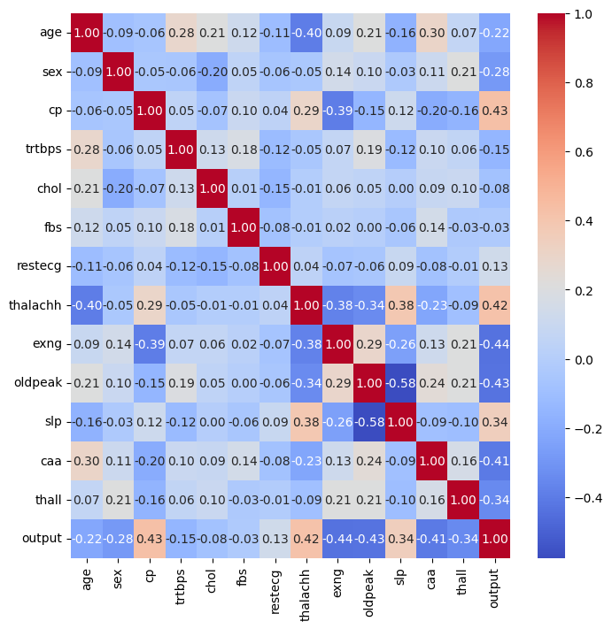

```python
import seaborn as sns
import matplotlib.pyplot as plt
plt.figure(figsize = (8,8))

sns.heatmap(df.corr(), annot=True, cmap='coolwarm',  fmt='.2f')

plt.show()
```

Ahora, debido a que tenemos 13 variables predictoras y 1 variable respuesta, vamos a separar el conjunto en 2 e intentar reducir el número de variables predictoras sin que afecte significativamente a la variabilidad. Para ello haremos un analisis de componentes principales.

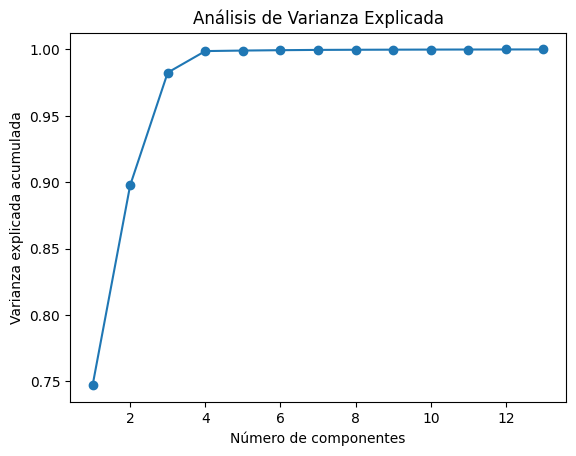

```python
ans = df['output']
pred = df.drop('output', axis=1)

from sklearn.decomposition import PCA

pca = PCA()
pca.fit(pred)
import numpy as np
varianza_acumulada = np.cumsum(pca.explained_variance_ratio_)
plt.plot(range(1, len(varianza_acumulada) + 1), varianza_acumulada, marker='o')
plt.xlabel('Número de componentes')
plt.ylabel('Varianza explicada acumulada')
plt.title('Análisis de Varianza Explicada')
plt.show()
```

Utilizando la regla del codo, escogemos 4 componentes principales. Que explican más del 99% de la muestra.

```python
pca = PCA(n_components = 4)
pred_pca = pca.fit_transform(pred)
component_weights = pca.components_[:4]
print(pd.DataFrame(component_weights, columns=pred.columns))
```

```
        age       sex        cp    trtbps      chol       fbs   restecg  \
0  0.038157 -0.001766 -0.001448  0.048525  0.998074  0.000104 -0.001520
1  0.181008  0.000818 -0.012443  0.107792 -0.016924  0.000450 -0.001162
2  0.126361 -0.001094  0.006147  0.981602 -0.051934  0.003684 -0.002748
3  0.974143 -0.004525  0.009640 -0.149362 -0.029224  0.003349 -0.002752

   thalachh      exng   oldpeak       slp       caa     thall
0 -0.004797  0.000603  0.001238 -0.000042  0.001762  0.001161
1 -0.977020  0.007536  0.017887 -0.010382  0.010650  0.002574
2  0.132770 -0.000047  0.009221 -0.002308  0.003736  0.001228
3  0.164535 -0.007121 -0.001178  0.003464  0.024771 -0.000980
```

Como vemos, la primera componente principal está muy relacionada con el colesterol, la segunda con la frecuencia cardiaca máxima, la tercera con la presión arterial y la cuarta con la edad.

Estos resultados hacen pensar que no sería necesario utilizar componentes principales ya que quedandonos con las cuatro variables citadas podríamos tener resultados parecidos en términos de variabilidad.

### **3. Limpieza de datos**

##### **3.1. ¿Los datos contienen ceros o elementos vacíos? Gestiona cada uno de estos casos.**

```python
# % de Valores nulos
df.isnull().sum()/len(df)*100
```

```
age         0.0
sex         0.0
cp          0.0
trtbps      0.0
chol        0.0
fbs         0.0
restecg     0.0
thalachh    0.0
exng        0.0
oldpeak     0.0
slp         0.0
caa         0.0
thall       0.0
output      0.0
dtype: float64
```

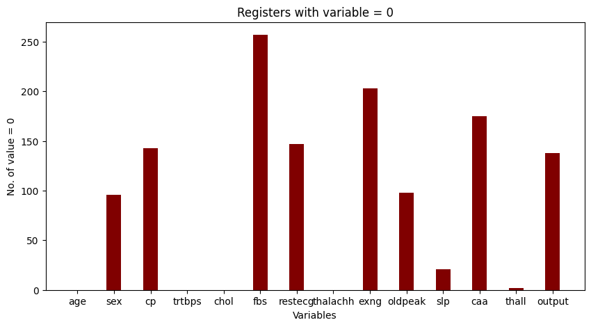

```python
# Gráfico con valores 0
col_names = [col for col in df.columns]
zeros_dict = {}

for col in col_names:
    zeros_dict[col] = df.loc[df[col] == 0].shape[0]

fig = plt.figure(figsize = (10, 5))
plt.bar(col_names, zeros_dict.values(), color ='maroon',
        width = 0.4)

plt.xlabel("Variables")
plt.ylabel("No. of value = 0")
plt.title("Registers with variable = 0")
plt.show()
```

No hay valores nulos y los ceros representan datos de relevancia en nuestro conjunto por lo que no sería apropiado modificarlos.

##### **3.2. Identifica y gestiona los valores extremos.**

Para ello vamos a realizar un diagrama de cajas de todas las variables y analizar el uso de outliers.

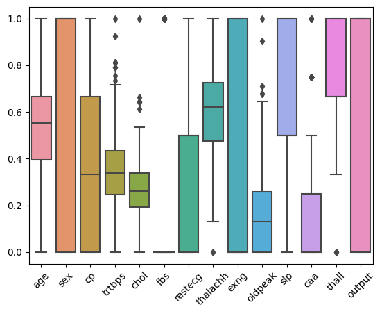

```python
from sklearn import preprocessing
import pandas as pd
#Normalizamos el set para representar todas las variables en un df
min_max_scaler = preprocessing.MinMaxScaler()
df_normalized = pd.DataFrame(min_max_scaler.fit_transform(df), columns=df.columns)

sns.boxplot(df_normalized)
plt.xticks(rotation = 45)
plt.show()
```

Como podemos observar en el gráfico, las variables age, sex, cp, restecg, exng, sip y output no contienen ningún valor fuera del rango intercuartílico.

Para fbs si que existe outliers que toman distancia con el resto de datos, pero viendo la naturaleza del atributo consideramos dejar estos valores. Además no tenemos una muesta suficientemente grande como para poder despreciar estos valores.

### **4. Analisis de datos**

#### **4.1 Selección de los grupos de datos que se quieren analizar/comparar (p.ej., si se van a comparar grupos de datos, ¿cuáles son estos grupos y qué tipo de análisis se van a aplicar?**

Vamos a realizar predicciones utilizando el conjunto de datos original y un conjunto donde sólo tendremos las 4 componentes principales. Para ello vamos a dividir los conjuntos entre los datos de entrenamiento y test.

Vamos a probar diferentes modelos de clasificación en los dos conjuntos para quedarnos con el modelo que mejor clasifique.

```python
from sklearn.model_selection import train_test_split
ans = pd.DataFrame(ans, columns = ['output'])
pred_train, pred_test, ans_train, ans_test = train_test_split(pred, ans, test_size = 0.2, random_state = 42)

pred_pca = pd.DataFrame(pred_pca, columns=['PCA1', 'PCA2', 'PCA3', 'PCA4'])
pred_pca_train, pred_pca_test, ans_pca_train, ans_pca_test = train_test_split(pred_pca, ans, test_size = 0.2, random_state = 42)

print('Dimensiones de los conjuntos de entrenamiento predictivos:\n Original:', pred_train.shape, '\n PCA:', pred_pca_train.shape)
print('Dimensiones de los conjuntos de validacion predictivos:\n Original:', pred_test.shape, '\n PCA:', pred_pca_test.shape)
print('Dimensiones de la variable respuesta de entrenamiento:\n Original:', ans_train.shape, '\n PCA:', ans_pca_train.shape)
print('Dimensiones de la variable respuesta de validacion:\n Original:', ans_test.shape, '\n PCA:', ans_pca_test.shape)
```

```
Dimensiones de los conjuntos de entrenamiento predictivos:
 Original: (241, 13)
 PCA: (241, 4)
Dimensiones de los conjuntos de validacion predictivos:
 Original: (61, 13)
 PCA: (61, 4)
Dimensiones de la variable respuesta de entrenamiento:
 Original: (241, 1)
 PCA: (241, 1)
Dimensiones de la variable respuesta de validacion:
 Original: (61, 1)
 PCA: (61, 1)
```

#### **4.2 Comprobación de la normalidad y homogeneidad de la varianza**

Comenzamos utilizando un gráfico Q-Q para visualizar si los datos siguen una distribución normal a priori.

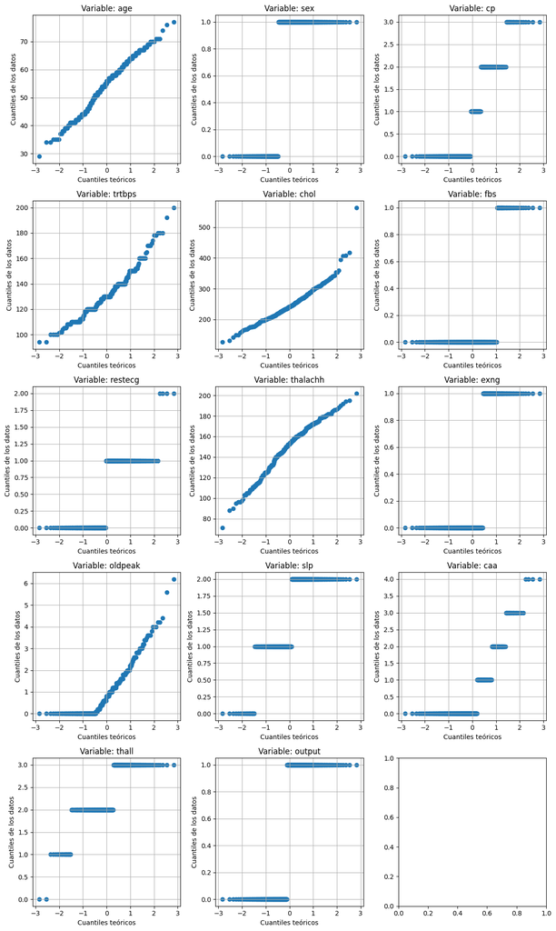

```python
import scipy.stats as stats
import matplotlib.pyplot as plt
import numpy as np

# Obtener el número de variables
num_variables = len(df.columns)

# Calcular los cuantiles teóricos esperados para una distribución normal para cada variable
cuantiles_teoricos = [stats.probplot(df[column], dist="norm")[0] for column in df.columns]

# Configurar la disposición de los subplots
num_filas = int(np.ceil(num_variables / 3))
fig, axes = plt.subplots(num_filas, 3, figsize=(12, 4*num_filas))
axes = axes.flatten()

# Trazar los gráficos Q-Q para cada variable
for i, (column, ax) in enumerate(zip(df.columns, axes)):
    ax.scatter(cuantiles_teoricos[i][0], cuantiles_teoricos[i][1])
    ax.set_xlabel('Cuantiles teóricos')
    ax.set_ylabel('Cuantiles de los datos')
    ax.set_title(f'Variable: {column}')
    ax.grid(True)

# Ajustar la disposición y espaciado de los subplots
plt.tight_layout()

# Mostrar la figura
plt.show()
```

Viendo la gráfica podemos ver que atributos se asemejan más a una línea diagonal. Para el resto de variables podemos descartar la normalidad. Por ello, vamos a contrastar la normalidad utilizando el test de shaphiro - wilk en las variables thalachh, chol, trtbps y age.

```python
df_tonorm = df[['age','chol','trtbps','thalachh']]

umbral = 0.05

for col in df_tonorm.columns:
  _, p_value = stats.shapiro(df_tonorm[col])

  if p_value < umbral:
    print(f"Variable: {col} - No sigue una distribución normal")
  else:
    print(f"Variable: {col} - Sigue una distribución normal")
```

```
Variable: age - No sigue una distribución normal
Variable: chol - No sigue una distribución normal
Variable: trtbps - No sigue una distribución normal
Variable: thalachh - No sigue una distribución normal
```

Para la homogeneidad vamos a utilizar la prueba de Levene:

```python
import scipy.stats as stats

resultados = df.apply(lambda col: stats.levene(col, df['output']))

for columna, resultado in resultados.items():
    estadistico = resultado[0]
    p_valor = resultado[1]
    print(f"Variable: {columna} - Estadístico de Levene: {estadistico} - Valor de p: {p_valor}")

umbral = 0.05
variables_homogeneas = [columna for columna, resultado in resultados.items() if resultado[1] >= umbral]
variables_no_homogeneas = [columna for columna, resultado in resultados.items() if resultado[1] < umbral]

print("Variables homogéneas:", variables_homogeneas)
print("Variables no homogéneas:", variables_no_homogeneas)
```

```
Variable: age - Estadístico de Levene: 511.18509081481835 - Valor de p: 2.0983383985883534e-82
Variable: sex - Estadístico de Levene: 12.520373514431238 - Valor de p: 0.0004335665079965192
Variable: cp - Estadístico de Levene: 128.54601924958476 - Valor de p: 3.859881591761161e-27
Variable: trtbps - Estadístico de Levene: 376.3815644757618 - Valor de p: 1.713232260036846e-65
Variable: chol - Estadístico de Levene: 376.67458007611043 - Valor de p: 1.5651965773945395e-65
Variable: fbs - Estadístico de Levene: 76.12799368365644 - Valor de p: 2.6005429482696998e-17
Variable: restecg - Estadístico de Levene: 1.1196487134901945 - Valor de p: 0.2904185052516097
Variable: thalachh - Estadístico de Levene: 485.74564178620426 - Valor de p: 2.2384377272488588e-79
Variable: exng - Estadístico de Levene: 10.71452643403777 - Valor de p: 0.0011238715167582894
Variable: oldpeak - Estadístico de Levene: 72.70826681704746 - Valor de p: 1.2150200134161038e-16
Variable: slp - Estadístico de Levene: 3.8262711864406747 - Valor de p: 0.0509171103696526
Variable: caa - Estadístico de Levene: 16.368587984141506 - Valor de p: 5.893312911011728e-05
Variable: thall - Estadístico de Levene: 0.006473535927049122 - Valor de p: 0.9358995108138496
Variable: output - Estadístico de Levene: 0.0 - Valor de p: 1.0
Variables homogéneas: ['restecg', 'slp', 'thall', 'output']
Variables no homogéneas: ['age', 'sex', 'cp', 'trtbps', 'chol', 'fbs', 'thalachh', 'exng', 'oldpeak', 'caa']
```

### Comparar si la diferencia en la probabilidad de ataque al corazón entre hombres y mujeres es significativa

Como primer análsis, comprobaremos si existe diferencia en la probabilidad de sufrir un ataque al corazón en función del sexo. Dado que nuestas variables no están distribuidas normalmente y no todas son homogéneas, tendremos que utilizar tests no paramétricos como chi-square y fisher_exact.

```python
from scipy.stats import chi2_contingency

umbral = 0.05
contingency_table = pd.crosstab(df['sex'], df['output'])
chi2, p_value, _, _ = chi2_contingency(contingency_table)

if p_value < umbral:
    print("Hay una diferencia significativa en la probabilidad de sufrir un ataque al corazón"
          + " entre mujeres y hombres")
else:
    print("No hay una diferencia significativa en la probabilidad de sufrir un ataque al corazón"
          + " entre mujeres y hombres")
```

```
Hay una diferencia significativa en la probabilidad de sufrir un ataque al corazón entre mujeres y hombres
```

```python
from scipy.stats import fisher_exact

odds_ratio, p_value = fisher_exact(contingency_table)

if p_value < umbral:
    print("Hay una diferencia significativa en la probabilidad de sufrir un ataque al corazón"
          + " entre mujeres y hombres")
else:
    print("No hay una diferencia significativa en la probabilidad de sufrir un ataque al corazón"
          + " entre mujeres y hombres")
```

```
Hay una diferencia significativa en la probabilidad de sufrir un ataque al corazón entre mujeres y hombres
```

```python
# Calcular probabilidades para cada género
p_females = contingency_table[1][0] / (contingency_table[0][0] + contingency_table[1][0])
p_males = contingency_table[1][1] / (contingency_table[0][1] + contingency_table[1][1])

print(f'Las mujeres tienen un {round(p_females - p_males, 2) * 100}% de posibilidades'
      + ' más de sufrir un ataque al corazón que los hombres')
```

```
Las mujeres tienen un 30.0% de posibilidades más de sufrir un ataque al corazón que los hombres
```

Tal y como muestran los resultados, parece que las muejres tienen un 30% más de probabilidades de sufrir un ataque al corazón que los hombres. A pesar de los resultados, hay que destacar que como ya hemos mencionado, tenemos muy pocos datos y es posible que la muestra no sea suficientemente representativa y por lo tanto, que las conclusiones sean incorrectas.

### Regresión para predecir los ataques al corazón

```python
import statsmodels.api as sm

# Añadimos una constante a las varaibles predictoras
X = sm.add_constant(pred_train)

# Creamos y entrenamos el modelo Logit
logit_model = sm.Logit(ans_train, X)
m1_result = logit_model.fit()
print(m1_result.summary())
print(f'Valor del criterio de Akaike: {m1_result.aic}')
```

```
Optimization terminated successfully.
         Current function value: 0.347733
         Iterations 7
                           Logit Regression Results
==============================================================================
Dep. Variable:                 output   No. Observations:                  241
Model:                          Logit   Df Residuals:                      227
Method:                           MLE   Df Model:                           13
Date:                Sun, 11 Jun 2023   Pseudo R-squ.:                  0.4950
Time:                        10:16:34   Log-Likelihood:                -83.804
converged:                       True   LL-Null:                       -165.95
Covariance Type:            nonrobust   LLR p-value:                 2.662e-28
==============================================================================
                 coef    std err          z      P>|z|      [0.025      0.975]
------------------------------------------------------------------------------
const          3.8752      2.924      1.325      0.185      -1.855       9.606
age            0.0028      0.026      0.110      0.913      -0.048       0.053
sex           -1.8149      0.523     -3.467      0.001      -2.841      -0.789
cp             0.6955      0.202      3.450      0.001       0.300       1.091
trtbps        -0.0279      0.012     -2.393      0.017      -0.051      -0.005
chol          -0.0045      0.004     -1.068      0.285      -0.013       0.004
fbs            0.5405      0.637      0.849      0.396      -0.708       1.789
restecg        0.5445      0.395      1.380      0.168      -0.229       1.318
thalachh       0.0251      0.012      2.098      0.036       0.002       0.049
exng          -1.1128      0.465     -2.391      0.017      -2.025      -0.200
oldpeak       -0.4721      0.253     -1.867      0.062      -0.968       0.023
slp            0.8707      0.391      2.227      0.026       0.104       1.637
caa           -0.8744      0.244     -3.587      0.000      -1.352      -0.397
thall         -1.1090      0.346     -3.206      0.001      -1.787      -0.431
==============================================================================
Valor del criterio de Akaike: 195.60719147005108
```

Podemos observar que tenemos un R-squared de 0.4950, indicando que un 49,50% de la variación de la variable dependiente es explicada por las variables independientes. Nos encontramos con que algunas variables no son significativas.

Para intentar simplificar el modelo, podemos intentar prescindir de las variables no significativas. A pesar de hacer esto, cabe destacar que las variables no significativas son un poco sospechosas, pues la edad y el colesterol son factores que generalmente influyen en la probabilidad de sufrir un ataque al corazón. Que las variables no sean significativas puede darse por varios problemas, entre ellos la poca cantidad de datos del dataset.

```python
pred_train_reduced = pred_train.drop(['age', 'chol', 'fbs', 'restecg'], axis=1)

# Añadimos una constante a las varaibles predictoras
X = sm.add_constant(pred_train_reduced)

# Creamos y entrenamos el modelo Logit
logit_model = sm.Logit(ans_train, X)
m2_result = logit_model.fit()
print(m2_result.summary())
print(f'Valor del criterio de Akaike: {m2_result.aic}')
```

```
Optimization terminated successfully.
         Current function value: 0.356770
         Iterations 7
                           Logit Regression Results
==============================================================================
Dep. Variable:                 output   No. Observations:                  241
Model:                          Logit   Df Residuals:                      231
Method:                           MLE   Df Model:                            9
Date:                Sun, 11 Jun 2023   Pseudo R-squ.:                  0.4819
Time:                        10:16:34   Log-Likelihood:                -85.982
converged:                       True   LL-Null:                       -165.95
Covariance Type:            nonrobust   LLR p-value:                 7.660e-30
==============================================================================
                 coef    std err          z      P>|z|      [0.025      0.975]
------------------------------------------------------------------------------
const          3.4999      2.227      1.571      0.116      -0.866       7.866
sex           -1.6185      0.474     -3.414      0.001      -2.548      -0.689
cp             0.6983      0.194      3.592      0.000       0.317       1.079
trtbps        -0.0280      0.011     -2.545      0.011      -0.049      -0.006
thalachh       0.0236      0.011      2.222      0.026       0.003       0.044
exng          -1.0634      0.456     -2.331      0.020      -1.958      -0.169
oldpeak       -0.4813      0.239     -2.017      0.044      -0.949      -0.014
slp            0.8061      0.370      2.181      0.029       0.082       1.531
caa           -0.8201      0.229     -3.575      0.000      -1.270      -0.370
thall         -1.1356      0.334     -3.399      0.001      -1.790      -0.481
==============================================================================
Valor del criterio de Akaike: 191.96334474882084
```

Si nos basamos en el valor del criterio de Akaike entre los dos modelos construidos, vemos como sin las variables no significativas lo hemos reducido, por lo que habríamos mejorado el modelo prescindiendo de estas. Probemos ahora utilizando los PCA calculados anteriormente.

```python
import statsmodels.api as sm

pred_pca_train_logit = pred_pca_train.copy()
ans_pca_train_logit = ans_pca_train.copy()
ans_pca_train_logit.reset_index(drop=True, inplace=True)

# Añadimos una constante a las varaibles predictoras
X = sm.add_constant(pred_pca_train_logit)
X.reset_index(drop=True, inplace=True)

# Creamos y entrenamos el modelo Logit
logit_model = sm.Logit(ans_pca_train_logit, X)
m3_result = logit_model.fit()
print(m3_result.summary())
print(f'Valor del criterio de Akaike: {m3_result.aic}')
```

```
Optimization terminated successfully.
         Current function value: 0.589006
         Iterations 5
                           Logit Regression Results
==============================================================================
Dep. Variable:                 output   No. Observations:                  241
Model:                          Logit   Df Residuals:                      236
Method:                           MLE   Df Model:                            4
Date:                Sun, 11 Jun 2023   Pseudo R-squ.:                  0.1446
Time:                        10:16:34   Log-Likelihood:                -141.95
converged:                       True   LL-Null:                       -165.95
Covariance Type:            nonrobust   LLR p-value:                 9.448e-10
==============================================================================
                 coef    std err          z      P>|z|      [0.025      0.975]
------------------------------------------------------------------------------
const          0.1949      0.144      1.355      0.175      -0.087       0.477
PCA1          -0.0028      0.003     -1.060      0.289      -0.008       0.002
PCA2          -0.0439      0.007     -5.955      0.000      -0.058      -0.029
PCA3          -0.0114      0.008     -1.386      0.166      -0.028       0.005
PCA4           0.0029      0.018      0.155      0.877      -0.033       0.039
==============================================================================
Valor del criterio de Akaike: 293.9007125789738
```

Si observamos el valor del criterio de Akaike, éste ha incrementado significativamente, por lo que para la regresión logística nos quedaríamos con el segundo modelo para intentar predecir las probabilidades de ataque al corazón. Ahora podemos probar de utilizar el modelo con los datos de test para ver cómo se comporta.

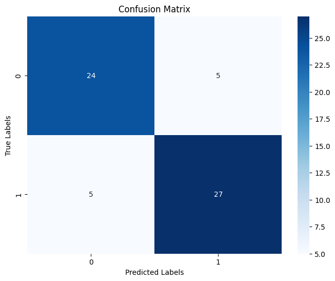

```python
import matplotlib.pyplot as plt
from sklearn import metrics
pred_test_reduced = pred_test.drop(['age', 'chol', 'fbs', 'restecg'], axis=1)

predicted_probabilities = []
values = []

# Cogemos los valores de test
for row in pred_test_reduced.iterrows():
    values.append([arr for arr in row[1].values])

# Añadimos la constante a los valores de test
values = sm.add_constant(values)
for arr in values:
    predicted_probabilities.append(m2_result.predict(arr))

# Convert predicted probabilities to binary labels
predicted_labels = [1 if p >= 0.5 else 0 for p in predicted_probabilities]

# Create confusion matrix
cm = metrics.confusion_matrix(predicted_labels, ans_test)
plt.figure(figsize=(8, 6))
sns.heatmap(cm, annot=True, cmap="Blues", fmt="d")
plt.title("Confusion Matrix")
plt.xlabel("Predicted Labels")
plt.ylabel("True Labels")
plt.show()
```

Vemos que el modelo ha funcionado bastante bien, prediciendo correctamente la mayoría de las veces utilizando los datos de test.

Veamos ahora otro tipo de modelo, random forest. En esta ocasión primero escogeremos el número de estimadores en función del que de mejores resultados. Generaremos uno con el dataset que incluye PCA y otro con el que no.

### Random forest sin PCA

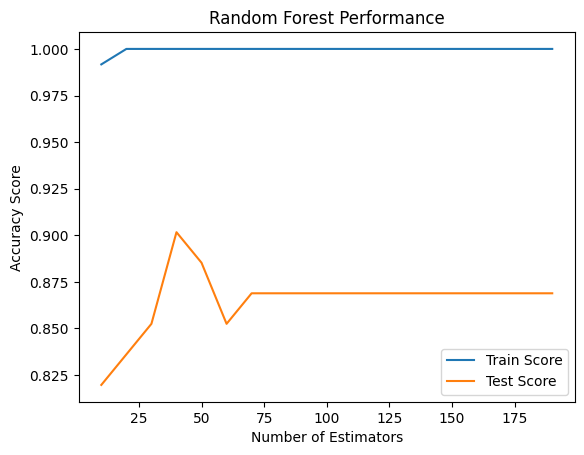

```
Best number of estimators: 40
```

```python
from sklearn.ensemble import RandomForestClassifier
from sklearn.metrics import accuracy_score

def serach_best_n_estimators(x_train, y_train, x_test, y_test):
    # Establecer rango de estimadores para probar
    estimator_range = range(10, 200, 10)

    # Listas donde guardaremos los resultados
    train_scores = []
    test_scores = []
    best_score = 0
    best_n_estimators = 0

    for n_estimators in estimator_range:
        # Crear random forest classifier
        rf_classifier = RandomForestClassifier(n_estimators=n_estimators, random_state=42)

        # Entrenar el modelo
        rf_classifier.fit(x_train, y_train)

        # Hacer predicciones
        train_predictions = rf_classifier.predict(x_train)
        test_predictions = rf_classifier.predict(x_test)

        # Calcular los resultados
        train_score = accuracy_score(y_train, train_predictions)
        test_score = accuracy_score(y_test, test_predictions)

        # Guardar los resultados
        train_scores.append(train_score)
        test_scores.append(test_score)

        # Guardar el número de estimadores con mejor resultado
        if test_score > best_score:
            best_score = test_score
            best_n_estimators = n_estimators

    # Graficar
    plt.plot(estimator_range, train_scores, label='Train Score')
    plt.plot(estimator_range, test_scores, label='Test Score')
    plt.xlabel('Number of Estimators')
    plt.ylabel('Accuracy Score')
    plt.title('Random Forest Performance')
    plt.legend()
    plt.show()

    # Mejor número de estimadores
    print(f'Best number of estimators: {best_n_estimators}')

    return best_n_estimators

best_n_estimators = serach_best_n_estimators(
    x_train=pred_train, y_train=ans_train,
    x_test=pred_test, y_test=ans_test
)
```

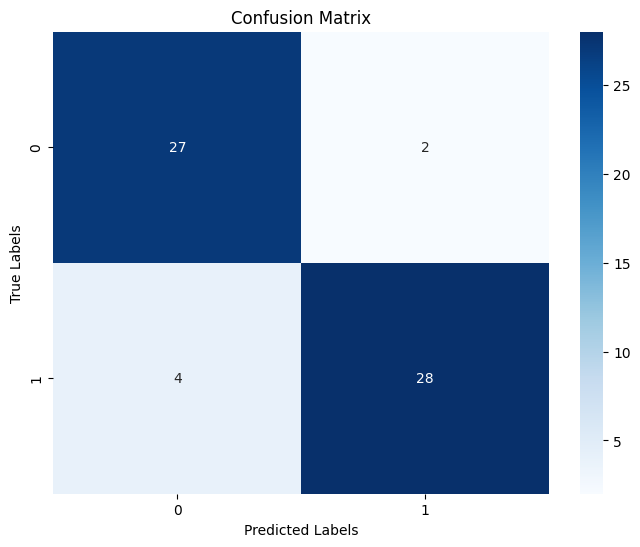

```python
from sklearn.ensemble import RandomForestClassifier
from sklearn.metrics import confusion_matrix

rf_classifier = RandomForestClassifier(n_estimators=best_n_estimators, random_state=42)
rf_classifier.fit(pred_train, ans_train)
y_pred_proba = rf_classifier.predict_proba(pred_test)[:, 1]
y_pred = (y_pred_proba >= 0.5).astype(int)

cm = confusion_matrix(ans_test, y_pred)
plt.figure(figsize=(8, 6))
sns.heatmap(cm, annot=True, cmap="Blues", fmt="d")
plt.title("Confusion Matrix")
plt.xlabel("Predicted Labels")
plt.ylabel("True Labels")
plt.show()
```

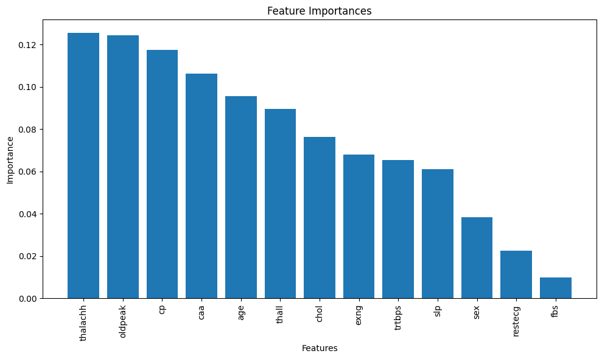

```python
importances = rf_classifier.feature_importances_
feature_names = pred_train.columns
indices = np.argsort(importances)[::-1]

plt.figure(figsize=(10, 6))
plt.title("Feature Importances")
plt.bar(range(len(indices)), importances[indices], align="center")
plt.xticks(range(len(indices)), feature_names[indices], rotation=90)
plt.xlabel("Features")
plt.ylabel("Importance")
plt.tight_layout()
plt.show()
```

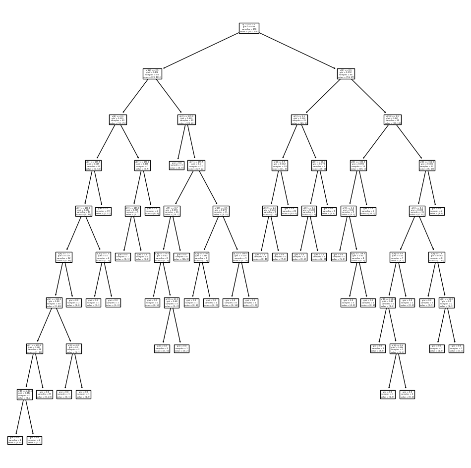

```python
from sklearn import tree
import matplotlib.pyplot as plt

tree_to_visualize = rf_classifier.estimators_[0]

fig, ax = plt.subplots(figsize=(12, 12))
tree.plot_tree(tree_to_visualize, ax=ax)
plt.show()
```

Observamos que los resultados son bastante buenos. Estos son ligeramente mejor a la regresión logística realizada y observamos que en este modelo la edad y el colesterol sí que han sido factores determinantes durante la predicción, destacando aún más las variables thalachh y oldpeak, que representan la frecuencia cardíaca máxima alcanzada y la depresión del segmento ST inducida por el ejercicio en relación con el descanso.

### Random forest con PCA

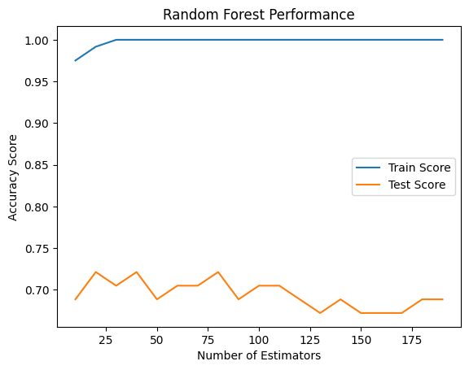

```
Best number of estimators: 20
```

```python
best_n_estimators = serach_best_n_estimators(
    x_train=pred_pca_train, y_train=ans_pca_train,
    x_test=pred_pca_test, y_test=ans_pca_test
)
```

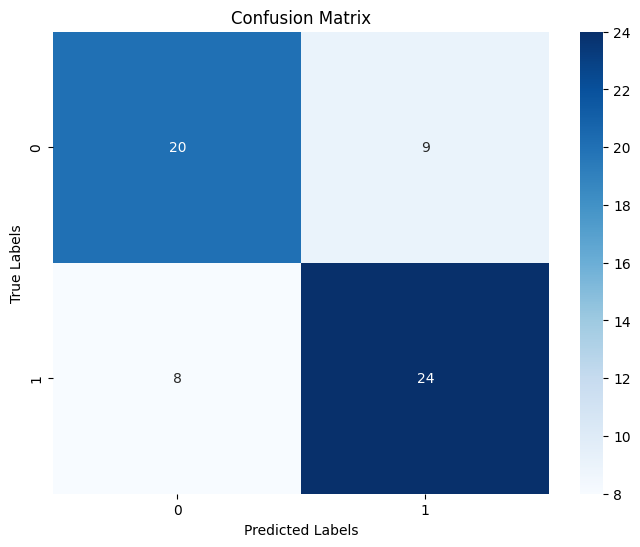

```python
from sklearn.ensemble import RandomForestClassifier
from sklearn.metrics import confusion_matrix

rf_classifier_pca = RandomForestClassifier(n_estimators=best_n_estimators, random_state=42)
rf_classifier_pca.fit(pred_pca_train, ans_pca_train)
y_pred_pca_proba = rf_classifier_pca.predict_proba(pred_pca_test)[:, 1]  # Predicted probabilities of positive class (heart attack)
y_pred_pca = (y_pred_pca_proba >= 0.5).astype(int)

cm_pca = confusion_matrix(ans_pca_test, y_pred_pca)
plt.figure(figsize=(8, 6))
sns.heatmap(cm_pca, annot=True, cmap="Blues", fmt="d")
plt.title("Confusion Matrix")
plt.xlabel("Predicted Labels")
plt.ylabel("True Labels")
plt.show()
```

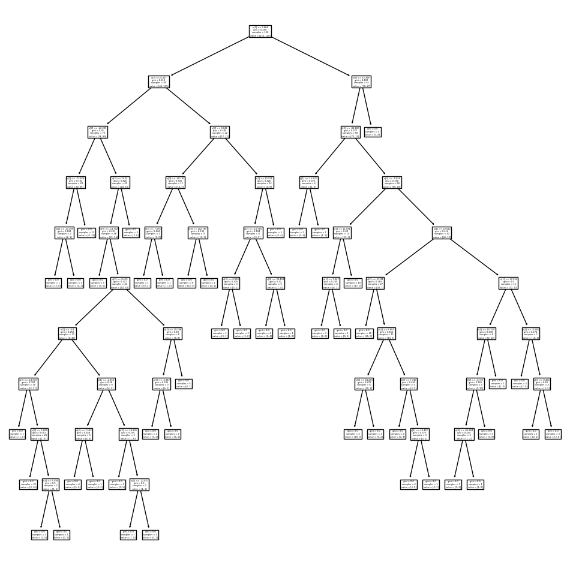

```python
from sklearn import tree

tree_to_visualize = rf_classifier_pca.estimators_[0]
fig, ax = plt.subplots(figsize=(12, 12))
tree.plot_tree(tree_to_visualize, ax=ax)
plt.show()
```

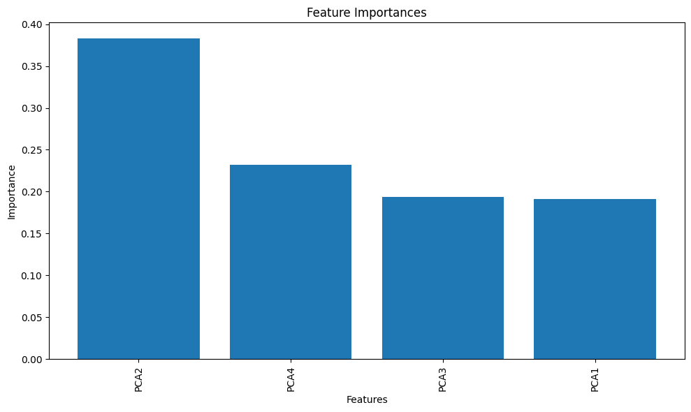

```python
importances = rf_classifier_pca.feature_importances_
feature_names = pred_pca_train.columns
indices = np.argsort(importances)[::-1]

plt.figure(figsize=(10, 6))
plt.title("Feature Importances")
plt.bar(range(len(indices)), importances[indices], align="center")
plt.xticks(range(len(indices)), feature_names[indices], rotation=90)
plt.xlabel("Features")
plt.ylabel("Importance")
plt.tight_layout()
plt.show()
```

De la misma manera que con la regresión logística, observamos que el modelo con únicamente PCA se comporta peor. Sin embargo, la utilización de únicamente 4 variables es algo que tendríamos en cuenta por su eficiencia en comparación con el modelo original. Asimismo, también se pueden probar modelos combinando variables originales con PCA.